# Partie 3 sur R

Clovis Deletre

Charles Vitry

# Import

▶ Importation du jeu d’entrainement & de test :

```r
library(readr)

df_train <-  read_csv("churner_train_data_set.csv")
df_test <- read_csv("churner_test_data_set.csv")
df_train_symbo <- read_delim("Train_Var_Symbolique.csv", delim = ";", escape_double = FALSE, trim_ws = TRUE)
df_test_symbo <- read_delim("Test_Var_Symbolique.csv", delim = ";", escape_double = FALSE, trim_ws = TRUE)
df_train_ACP <- read_csv("trainACP.csv")
```

```
## ──────────────────────────────────────────────────────── Delimiter: "," dbl
## (25): ...1, Axis1, Axis2, Axis3, Axis4, Axis5, Axis6, Axis7, Axis8, Axis... lgl
## (1): y
```

```r
df_test_ACP <- read_csv("testACP.csv")
```

```
## ──────────────────────────────────────────────────────── Delimiter: "," dbl
## (25): ...1, Axis1, Axis2, Axis3, Axis4, Axis5, Axis6, Axis7, Axis8, Axis... lgl
## (1): y.test
```

```r
df_train_ACP_symbo  <- read_delim("Train_Var_ACP.csv", delim = ";", escape_double = FALSE, trim_ws = TRUE)
df_test_ACP_symbo <- read_delim("Test_Var_ACP.csv", delim = ";", escape_double = FALSE, trim_ws = TRUE)
```

Corrections noms de variables à prédire

```r
df_train_ACP$...1 <- NULL
df_test_ACP$...1 <- NULL

names(df_train_ACP)[names(df_train_ACP) == "y"] <- "churner"
names(df_test_ACP)[names(df_test_ACP) == "y.test"] <- "churner"
```

Choix des jeux de données utilisés

```r
train <- df_train_ACP
test <- df_test_ACP
df <- rbind(train,test)
```

Les jeux d’entraînement et de test sont déjà prêt, on créé le jeu de validation à partir du jeu d’entraînement.

```r
split <- initial_split(train, prop = 4/5)
train <- training(split)
val <- testing(split)
```

# Analyse quantitative

▶ Analyse de la distribution de la variable “churner”

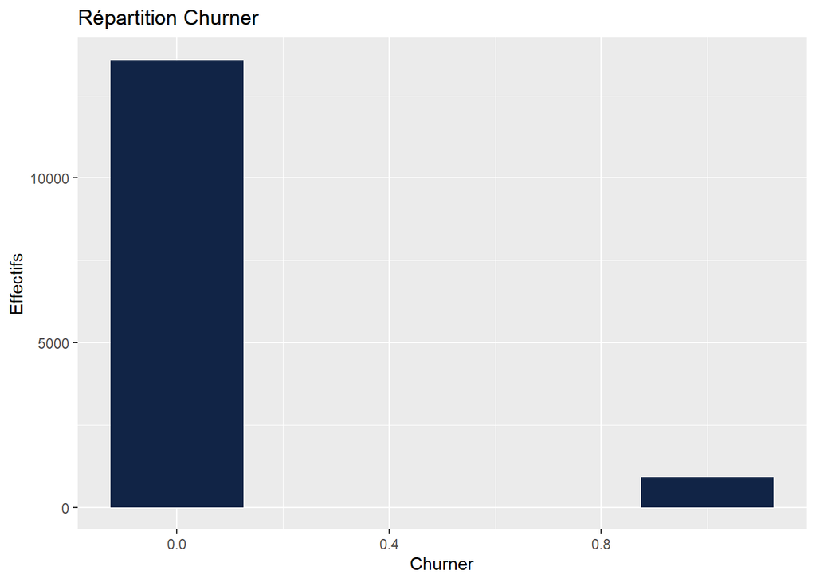

```r
ggplot(df_test) +
  aes(x = churner) +
  geom_histogram(bins = 5L, fill = "#112446") +
  labs(
    x = "Churner",
    y = "Effectifs",
    title = "Répartition Churner"
  ) +
  theme_gray()
```

# Préparation des batchs

Nous allons séparer en petites parties le jeu de donnée avec tfdatasets. Cela permet de former le modèle plus facilement.

```r
df_to_dataset <- function(df, shuffle = TRUE, batch_size = 1024) {
  ds <- df %>%
    tensor_slices_dataset()

  if (shuffle)
    ds <- ds %>% dataset_shuffle(buffer_size = nrow(df))

  ds %>%
    dataset_batch(batch_size = batch_size)
}
```

```r
batch_size <- 1024
train_ds <- df_to_dataset(train, batch_size = batch_size)
```

```
## Loaded Tensorflow version 2.8.0
```

```r
val_ds <- df_to_dataset(val, shuffle = FALSE, batch_size = batch_size)
test_ds <- df_to_dataset(test, shuffle = FALSE, batch_size = batch_size)
```

Observons la nature des données qui vont être utilisés

```r
train_ds %>%
  reticulate::as_iterator() %>%
  reticulate::iter_next() %>%
  str()
```

[output not shown]

Nous souhaitons prédire la variable churner

```r
spec <- feature_spec(train_ds, churner ~ .)
spec_prep <- spec
```

```r
spec <- spec %>%
  step_numeric_column(
    all_numeric()
  )
 spec_prep <- fit(spec)
 str(spec_prep$dense_features())
```

[output not shown]

# Création du modèle de Deep-Learning

Création du modèle

```r
model <- keras_model_sequential() %>%
  layer_dense_features(dense_features(spec_prep)) %>%
  layer_dense(units = 200, activation = "relu") %>%
  layer_dropout(0.5) %>%
  layer_dense(units = 100, activation = "relu") %>%
  layer_dropout(0.4) %>%
  layer_dense(units = 100, activation = "relu") %>%
  layer_dropout(0.3) %>%
  layer_dense(units = 100, activation = "relu") %>%
  layer_dropout(0.2) %>%
  layer_dense(units = 1, activation = 'sigmoid')


model %>% compile(
  loss = loss_binary_crossentropy,
  optimizer = "adam",
  metrics = "binary_accuracy"
)
```

Entrainement du modèle sur le jeu d’entraînement

```r
history <- model %>%
  fit(
    dataset_use_spec(train_ds, spec = spec_prep),
    epochs = 100,
    validation_data = dataset_use_spec(val_ds, spec_prep),
    verbose = 2
  )
```

# Visualisation des résultats

Affichage graphique des améliorations de l’entraînement

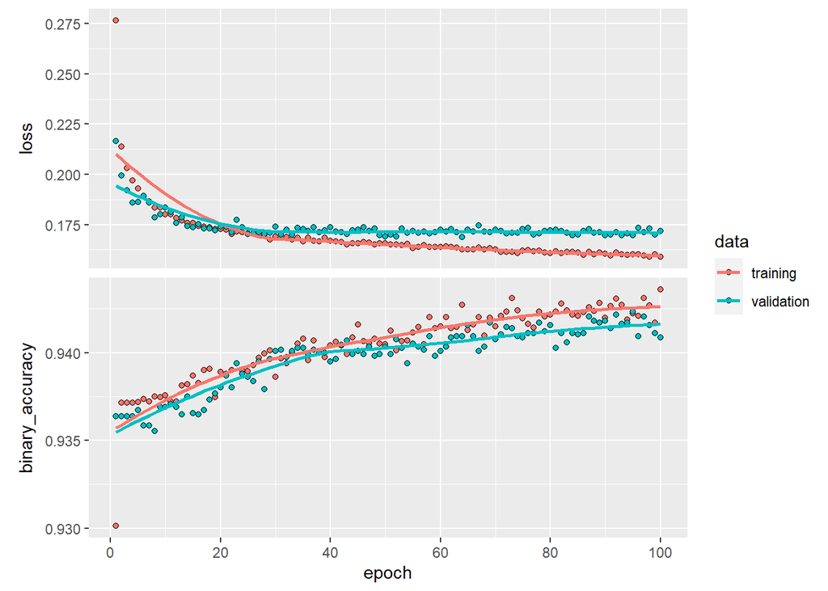

```r
plot(history)
```

Prédiction sur le jeu de test.

```r
#prédiction
pred <- predict(model, test)
test$prediction <- pred
```

```r
predictions = matrix(FALSE, nr = nrow(test), nc = 1)

for (i in 1:nrow(test)) {
  if (test[i, 26] > 0.5) {
    test[i, 26] = TRUE
  }
  else {
    test[i, 26] = FALSE
  }
}
```

```r
#Matrice de confusion
table(test[,25:26])
```

```
##        prediction
## churner     0     1
##   FALSE 13382   204
##   TRUE    664   249
```

On remarque que les modèles réalisés avec Keras produisent les mêmes résultats que ceux produits avec Pytorch, avec les mêmes paramètres évidemment.

Les deux librairies étant facile à utiliser et intuitives, il en va de la préférence du langage pour le choix de plateforme.

Le modèle pourra être utilisé plus tard.

```r
save_model_tf(model, "model/ChurnPrediction")
```